# (Prosper Loan Data Exploration)

## Preliminary Wrangling

```python
# import all packages and set plots to be embedded inline
import numpy as np
import pandas as pd
import matplotlib.pyplot as plt
import seaborn as sb

%matplotlib inline
```

```python
#Loading data
df = pd.read_csv('prosperLoanData.csv')
df.head()
```

|  | ListingKey | ListingNumber | ListingCreationDate | CreditGrade | Term | LoanStatus | ClosedDate | BorrowerAPR | BorrowerRate | LenderYield | ... | LP_ServiceFees | LP_CollectionFees | LP_GrossPrincipalLoss | LP_NetPrincipalLoss | LP_NonPrincipalRecoverypayments | PercentFunded | Recommendations | InvestmentFromFriendsCount | InvestmentFromFriendsAmount | Investors |
| --- | --- | --- | --- | --- | --- | --- | --- | --- | --- | --- | --- | --- | --- | --- | --- | --- | --- | --- | --- | --- | --- |
| 0 | 1021339766868145413AB3B | 193129 | 2007-08-26 19:09:29.263000000 | C | 36 | Completed | 2009-08-14 00:00:00 | 0.16516 | 0.1580 | 0.1380 | ... | -133.18 | 0.0 | 0.0 | 0.0 | 0.0 | 1.0 | 0 | 0 | 0.0 | 258 |
| 1 | 10273602499503308B223C1 | 1209647 | 2014-02-27 08:28:07.900000000 | NaN | 36 | Current | NaN | 0.12016 | 0.0920 | 0.0820 | ... | 0.00 | 0.0 | 0.0 | 0.0 | 0.0 | 1.0 | 0 | 0 | 0.0 | 1 |
| 2 | 0EE9337825851032864889A | 81716 | 2007-01-05 15:00:47.090000000 | HR | 36 | Completed | 2009-12-17 00:00:00 | 0.28269 | 0.2750 | 0.2400 | ... | -24.20 | 0.0 | 0.0 | 0.0 | 0.0 | 1.0 | 0 | 0 | 0.0 | 41 |
| 3 | 0EF5356002482715299901A | 658116 | 2012-10-22 11:02:35.010000000 | NaN | 36 | Current | NaN | 0.12528 | 0.0974 | 0.0874 | ... | -108.01 | 0.0 | 0.0 | 0.0 | 0.0 | 1.0 | 0 | 0 | 0.0 | 158 |
| 4 | 0F023589499656230C5E3E2 | 909464 | 2013-09-14 18:38:39.097000000 | NaN | 36 | Current | NaN | 0.24614 | 0.2085 | 0.1985 | ... | -60.27 | 0.0 | 0.0 | 0.0 | 0.0 | 1.0 | 0 | 0 | 0.0 | 20 |

5 rows × 81 columns

```python
#Printing number of columns and rows
df.shape
```

```
(113937, 81)
```

```python
df.describe()
```

|  | ListingNumber | Term | BorrowerAPR | BorrowerRate | LenderYield | EstimatedEffectiveYield | EstimatedLoss | EstimatedReturn | ProsperRating (numeric) | ProsperScore | ... | LP_ServiceFees | LP_CollectionFees | LP_GrossPrincipalLoss | LP_NetPrincipalLoss | LP_NonPrincipalRecoverypayments | PercentFunded | Recommendations | InvestmentFromFriendsCount | InvestmentFromFriendsAmount | Investors |
| --- | --- | --- | --- | --- | --- | --- | --- | --- | --- | --- | --- | --- | --- | --- | --- | --- | --- | --- | --- | --- | --- |
| count | 1.139370e+05 | 113937.000000 | 113912.000000 | 113937.000000 | 113937.000000 | 84853.000000 | 84853.000000 | 84853.000000 | 84853.000000 | 84853.000000 | ... | 113937.000000 | 113937.000000 | 113937.000000 | 113937.000000 | 113937.000000 | 113937.000000 | 113937.000000 | 113937.000000 | 113937.000000 | 113937.000000 |
| mean | 6.278857e+05 | 40.830248 | 0.218828 | 0.192764 | 0.182701 | 0.168661 | 0.080306 | 0.096068 | 4.072243 | 5.950067 | ... | -54.725641 | -14.242698 | 700.446342 | 681.420499 | 25.142686 | 0.998584 | 0.048027 | 0.023460 | 16.550751 | 80.475228 |
| std | 3.280762e+05 | 10.436212 | 0.080364 | 0.074818 | 0.074516 | 0.068467 | 0.046764 | 0.030403 | 1.673227 | 2.376501 | ... | 60.675425 | 109.232758 | 2388.513831 | 2357.167068 | 275.657937 | 0.017919 | 0.332353 | 0.232412 | 294.545422 | 103.239020 |
| min | 4.000000e+00 | 12.000000 | 0.006530 | 0.000000 | -0.010000 | -0.182700 | 0.004900 | -0.182700 | 1.000000 | 1.000000 | ... | -664.870000 | -9274.750000 | -94.200000 | -954.550000 | 0.000000 | 0.700000 | 0.000000 | 0.000000 | 0.000000 | 1.000000 |
| 25% | 4.009190e+05 | 36.000000 | 0.156290 | 0.134000 | 0.124200 | 0.115670 | 0.042400 | 0.074080 | 3.000000 | 4.000000 | ... | -73.180000 | 0.000000 | 0.000000 | 0.000000 | 0.000000 | 1.000000 | 0.000000 | 0.000000 | 0.000000 | 2.000000 |
| 50% | 6.005540e+05 | 36.000000 | 0.209760 | 0.184000 | 0.173000 | 0.161500 | 0.072400 | 0.091700 | 4.000000 | 6.000000 | ... | -34.440000 | 0.000000 | 0.000000 | 0.000000 | 0.000000 | 1.000000 | 0.000000 | 0.000000 | 0.000000 | 44.000000 |
| 75% | 8.926340e+05 | 36.000000 | 0.283810 | 0.250000 | 0.240000 | 0.224300 | 0.112000 | 0.116600 | 5.000000 | 8.000000 | ... | -13.920000 | 0.000000 | 0.000000 | 0.000000 | 0.000000 | 1.000000 | 0.000000 | 0.000000 | 0.000000 | 115.000000 |
| max | 1.255725e+06 | 60.000000 | 0.512290 | 0.497500 | 0.492500 | 0.319900 | 0.366000 | 0.283700 | 7.000000 | 11.000000 | ... | 32.060000 | 0.000000 | 25000.000000 | 25000.000000 | 21117.900000 | 1.012500 | 39.000000 | 33.000000 | 25000.000000 | 1189.000000 |

8 rows × 61 columns

```python
#create a copy to apply the columns of intrest
df_copy = df.copy()
df_copy.shape
```

```
(113937, 81)
```

### What is the structure of your dataset?

> Data contain 81 feature with total 113,937 loans.

### What is/are the main feature(s) of interest in your dataset?

> I'm interested to find out the best-fit prediction for Loan amounts and their correlations with other attributes

### What features in the dataset do you think will help support your investigation into your feature(s) of interest?

> I think that monthly income, loan term, borrowers stated, Prosper rating and employment status will play an important role so let's find out..

```python
#Listing columns of interest
interest_columns = ['Term', 'LoanStatus', 'BorrowerAPR', 'BorrowerRate','ProsperRating (Alpha)','Occupation','ListingCategory (numeric)', 'BorrowerState','EmploymentStatus','IsBorrowerHomeowner','IncomeRange','StatedMonthlyIncome','LoanOriginalAmount','LoanOriginationDate', 'Investors']
```

```python
loan_data = df_copy[interest_columns]
```

```python
loan_data.info()
```

```
<class 'pandas.core.frame.DataFrame'>
RangeIndex: 113937 entries, 0 to 113936
Data columns (total 15 columns):
 #   Column                     Non-Null Count   Dtype
---  ------                     --------------   -----
 0   Term                       113937 non-null  int64
 1   LoanStatus                 113937 non-null  object
 2   BorrowerAPR                113912 non-null  float64
 3   BorrowerRate               113937 non-null  float64
 4   ProsperRating (Alpha)      84853 non-null   object
 5   Occupation                 110349 non-null  object
 6   ListingCategory (numeric)  113937 non-null  int64
 7   BorrowerState              108422 non-null  object
 8   EmploymentStatus           111682 non-null  object
 9   IsBorrowerHomeowner        113937 non-null  bool
 10  IncomeRange                113937 non-null  object
 11  StatedMonthlyIncome        113937 non-null  float64
 12  LoanOriginalAmount         113937 non-null  int64
 13  LoanOriginationDate        113937 non-null  object
 14  Investors                  113937 non-null  int64
dtypes: bool(1), float64(3), int64(4), object(7)
memory usage: 12.3+ MB
```

```python
#removing Null values from ProsperRating and Occupation.
loan_data = loan_data.dropna(subset=['ProsperRating (Alpha)'])
loan_data = loan_data.dropna(subset=['Occupation'])

#Convert LoanOriginationDate to datetime datatype.
loan_data['LoanOriginationDate'] = pd.to_datetime(loan_data['LoanOriginationDate'])
```

```python
loan_data.info()
```

```
<class 'pandas.core.frame.DataFrame'>
Int64Index: 83520 entries, 1 to 113936
Data columns (total 15 columns):
 #   Column                     Non-Null Count  Dtype
---  ------                     --------------  -----
 0   Term                       83520 non-null  int64
 1   LoanStatus                 83520 non-null  object
 2   BorrowerAPR                83520 non-null  float64
 3   BorrowerRate               83520 non-null  float64
 4   ProsperRating (Alpha)      83520 non-null  object
 5   Occupation                 83520 non-null  object
 6   ListingCategory (numeric)  83520 non-null  int64
 7   BorrowerState              83520 non-null  object
 8   EmploymentStatus           83520 non-null  object
 9   IsBorrowerHomeowner        83520 non-null  bool
 10  IncomeRange                83520 non-null  object
 11  StatedMonthlyIncome        83520 non-null  float64
 12  LoanOriginalAmount         83520 non-null  int64
 13  LoanOriginationDate        83520 non-null  datetime64[ns]
 14  Investors                  83520 non-null  int64
dtypes: bool(1), datetime64[ns](1), float64(3), int64(4), object(6)
memory usage: 9.6+ MB
```

## Univariate Exploration

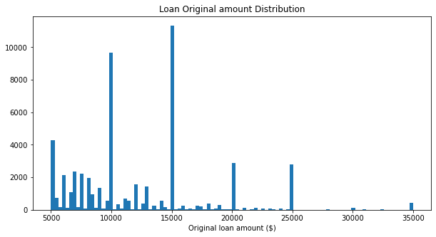

```python
#Plotting loan amount Distribution
bin = np.arange(5000, loan_data.LoanOriginalAmount.max()+300, 300)
plt.figure(figsize=[10, 5])
plt.hist(data = loan_data,  x='LoanOriginalAmount', bins = bin);
plt.xlabel('Original loan amount ($)');
plt.title('Loan Original amount Distribution');
```

> We can observe from the large spikes that most of the loans are multiples of 5K.

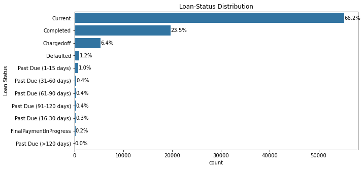

```python
#plotting loan Status Distribution
plt.figure(figsize = [10, 5])
base_color = sb.color_palette()[0]
LoanStatus_order = loan_data['LoanStatus'].value_counts().index
LoanStatus_counts = loan_data['LoanStatus'].value_counts()
n_LoanStatus = loan_data['LoanStatus'].value_counts().sum()
sb.countplot(data=loan_data, y='LoanStatus', color=base_color, order=LoanStatus_order);
plt.ylabel('Loan Status')
plt.title('Loan-Status Distribution');

# Logic to print the proportion text on the bars
for i in range (LoanStatus_counts.shape[0]):
    count = LoanStatus_counts[i]
    # Convert count into a percentage, and then into string
    pct_string = '{:0.1f}%'.format(100*count/n_LoanStatus)
    # Print the string value on the bar.
    plt.text(count+1, i, pct_string, va='center')
```

> The majority are `current loans`and the second big part are `completed loans`.

```python
loan_data.IncomeRange.value_counts()
```

```
$50,000-74,999    25293
$25,000-49,999    23574
$100,000+         15166
$75,000-99,999    14401
$1-24,999          4392
Not employed        649
$0                   45
Name: IncomeRange, dtype: int64
```

```python
# Convert IncomeRange ordered categorical types
Income_Range= ['$100,000+', '$75,000-99,999', '$50,000-74,999', '$25,000-49,999', '$1-24,999', '$0']
ordered_var = pd.api.types.CategoricalDtype(ordered = True, categories = Income_Range)
loan_data['IncomeRange'] = loan_data['IncomeRange'].astype(ordered_var)
```

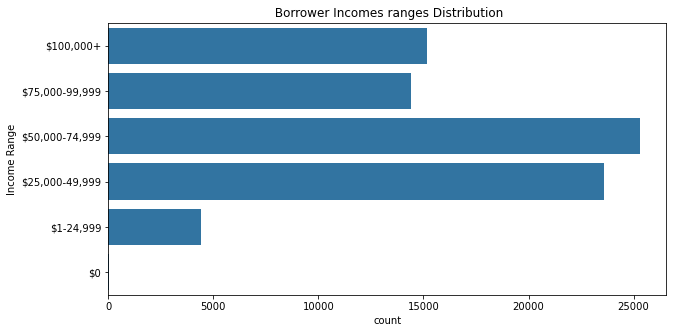

```python
#plotting Borrower Incomes ranges Distribution
plt.figure(figsize = [10, 5])
sb.countplot(data=loan_data, y='IncomeRange', color=base_color, order=Income_Range);
plt.ylabel('Income Range')
plt.title(' Borrower Incomes ranges Distribution');
```

> Number of Borrowers whose income between `$25K-49K` and between `$50K-74K` represent the largest part followed by `$100K+`

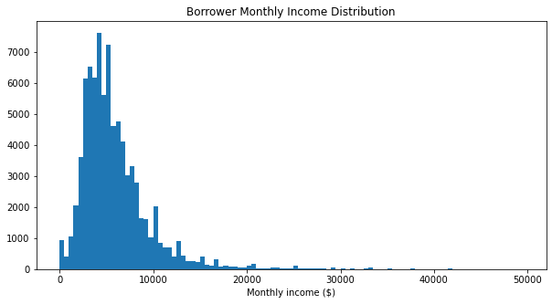

```python
#plotting Borrower Monthly Incomes Distribution.
plt.figure(figsize = [10, 5])
bins = np.arange(0, 50000, 500)
plt.hist(data=loan_data, x='StatedMonthlyIncome', bins=bins);
plt.xlabel('Monthly income ($)')
plt.title('Borrower Monthly Income Distribution');
```

> Borrower monthly income right screwed with peek around `5K`

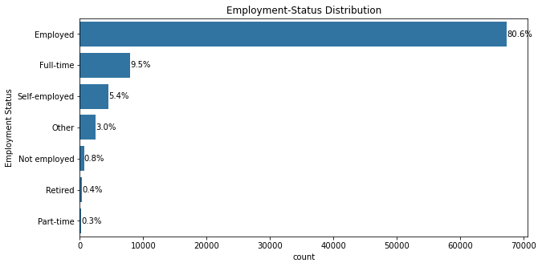

```python
#plotting Employment Status Distribution.
plt.figure(figsize = [10, 5])
base_color = sb.color_palette()[0]
EmploymentStatus_order = loan_data['EmploymentStatus'].value_counts().index
EmploymentStatus_counts = loan_data['EmploymentStatus'].value_counts()
n_EmploymentStatus = loan_data['EmploymentStatus'].value_counts().sum()
sb.countplot(data=loan_data, y='EmploymentStatus', color=base_color, order=EmploymentStatus_order);
plt.ylabel('Employment Status')
plt.title('Employment-Status Distribution');

# Logic to print the proportion text on the bars
for i in range (EmploymentStatus_counts.shape[0]):
    count = EmploymentStatus_counts[i]
    # Convert count into percentage then a string
    pct_string = '{:0.1f}%'.format(100*count/n_EmploymentStatus)
    # Print the string value on the bar.
    plt.text(count+1, i, pct_string, va='center')
```

> Most borrowers are `Employed`.

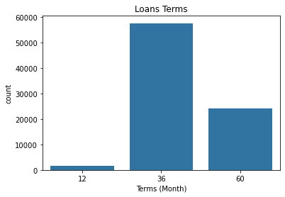

```python
#plotting Loan Terms Distribution.
sb.countplot(data=loan_data, x='Term', color=base_color);
plt.xlabel('Terms (Month)')
plt.title('Loans Terms');
```

> Seems that most of the borrowers prefer the moderated term which is `3-Years`.

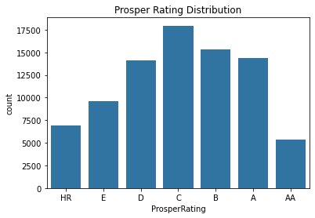

```python
# Convert ProsperRating ordered categorical types
Prosper_order = ['HR','E','D','C','B','A','AA']
ordered_var = pd.api.types.CategoricalDtype(ordered = True,categories = Prosper_order)
loan_data['ProsperRating (Alpha)'] = loan_data['ProsperRating (Alpha)'].astype(ordered_var)

#plotting Prosper Rating Distribution.
sb.countplot(data=loan_data, x='ProsperRating (Alpha)', color=base_color,order=Prosper_order);
plt.xlabel('ProsperRating')
plt.title('Prosper Rating Distribution');
```

> Most of the borrowers rating is between `"D to A"` with a high `C` rating.

```python
loan_data['BorrowerAPR'].describe()
```

```
count    83520.000000
mean         0.226863
std          0.080115
min          0.045830
25%          0.163280
50%          0.219450
75%          0.292540
max          0.423950
Name: BorrowerAPR, dtype: float64
```

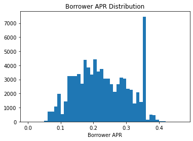

```python
#Adjusting Borrower APR bins on X-axis.
bins = np.arange(0, loan_data.BorrowerAPR.max()+0.05, 0.01)

#plotting Borrower APR Distribution
plt.hist(data = loan_data, x = 'BorrowerAPR', bins = bins);
plt.xlabel('Borrower APR');
plt.title('Borrower APR Distribution');
```

### Discuss the distribution(s) of your variable(s) of interest. Were there any unusual points? Did you need to perform any transformations?

> Borrower monthly income distribution is right screwed with peek around 5K, Most borrowers are Employed and regarding Loan origination amount Distribution We can observe from the large spikes that most of the loans are multiples of 5K and on the same time from the small spikes, we can say that the loan is multiples of 1K. No need to perform transformations.

### Of the features you investigated, were there any unusual distributions? Did you perform any operations on the data to tidy, adjust, or change the form of the data? If so, why did you do this?

> Borrower income range of `$0` does not make any sense, it might be missing data.

## Bivariate Exploration

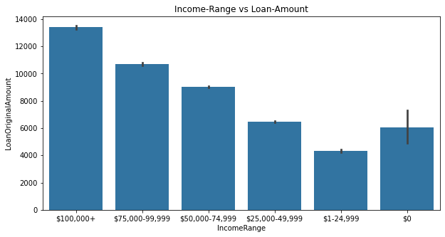

```python
plt.figure(figsize=[10,5]);
sb.barplot(data = loan_data, x = 'IncomeRange', y = 'LoanOriginalAmount', color = base_color);
plt.title('Income-Range vs Loan-Amount');
```

> As we can see, there is a positive correlation between income ranges and Loan amount as the income range increased the loan amount also increased except for the amount $0, as it was assumed before that it might be missing data

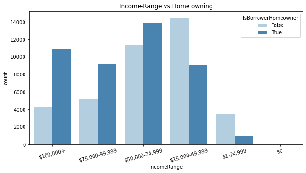

```python
plt.figure(figsize=[10,5])
sb.countplot(data = loan_data, x = 'IncomeRange', hue = 'IsBorrowerHomeowner', palette = 'Blues');
plt.xticks(rotation=15);
plt.title('Income-Range vs Home owning');
```

> As we can see, for the largest three income ranges, the borrower with a homeowner has the highest share

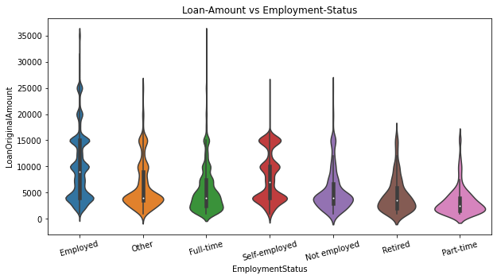

```python
plt.figure(figsize=[10,5])
sb.violinplot(data = loan_data, x = 'EmploymentStatus', y='LoanOriginalAmount')
plt.xticks(rotation=15)
plt.title('Loan-Amount vs Employment-Status');
```

> The highest borrowers Employment Status from the loan amount are the `Employed`

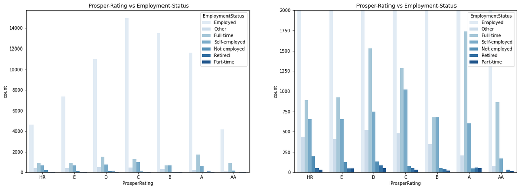

```python
plt.figure(figsize=[20,15]);

plt.subplot(2, 2, 1)
sb.countplot(data=loan_data, x='ProsperRating (Alpha)', hue = 'EmploymentStatus', palette = 'Blues');
plt.xlabel('ProsperRating')
plt.title(' Prosper-Rating vs Employment-Status');

plt.subplot(2, 2, 2)
sb.countplot(data=loan_data, x='ProsperRating (Alpha)', hue = 'EmploymentStatus', palette = 'Blues');
plt.xlabel('ProsperRating')
plt.ylim(0,2000,250)
plt.title(' Prosper-Rating vs Employment-Status');
```

The Lowest Prosper rating are `Not-employed`, `retired`, and `part-time`

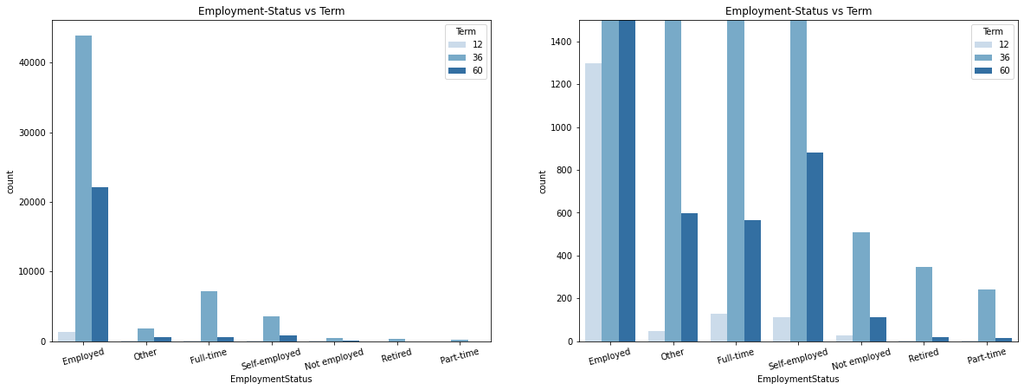

```python
plt.figure(figsize=[20,15]);

plt.subplot(2, 2, 1)
sb.countplot(data = loan_data, x = 'EmploymentStatus', hue = 'Term', palette = 'Blues')
plt.xticks(rotation=15)
plt.title('Employment-Status vs Term');

plt.subplot(2, 2, 2)
sb.countplot(data = loan_data, x = 'EmploymentStatus', hue = 'Term', palette = 'Blues')
plt.xticks(rotation=15)
plt.ylim(0,1500,150)
plt.title('Employment-Status vs Term');
```

> It appears that the `3-Year` term is the most preferable term among the Employment Status.

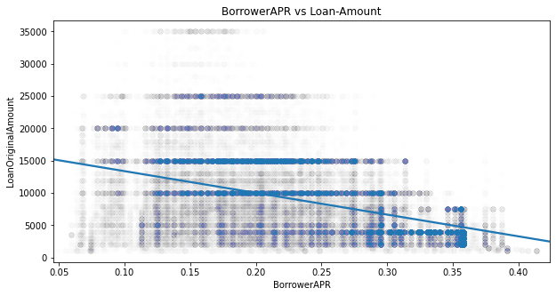

```python
plt.figure(figsize=[10,5]);
sb.regplot(data = loan_data, x = 'BorrowerAPR', y = 'LoanOriginalAmount', scatter_kws={'alpha':0.005});
plt.title('BorrowerAPR vs Loan-Amount');
```

> There is a negative correlation between the loan amount and borrower APR

### Talk about some of the relationships you observed in this part of the investigation. How did the feature(s) of interest vary with other features in the dataset?

> There is a `positive correlation` between income range and loan amount, also there is a relation with Employment Status as the highest borrowers share from the loan amount are the `Employed` also the `negative correlation` between the loan amount and the borrower's APR

### Did you observe any interesting relationships between the other features (not the main feature(s) of interest)?

> The Lowest Prosper ratings are`Not-employed`, `retired` and `part-time`

## Multivariate Exploration

[figure not shown]

```python
plt.figure(figsize=[10,5])
sb.barplot(data = loan_data, x = 'IncomeRange', y = 'LoanOriginalAmount', hue = 'Term');
plt.xticks(rotation = 15);
plt.title('Income-Range vs Loan-Amount and Term');
```

> The loan amount and terms increase with income range

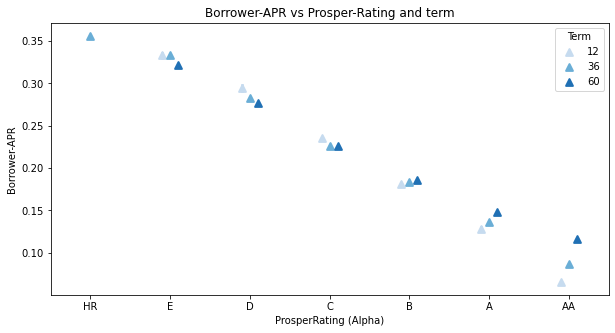

```python
fig = plt.figure(figsize = [10,5])
ax = sb.pointplot(data = loan_data, x = 'ProsperRating (Alpha)', y = 'BorrowerAPR', hue = 'Term',palette = 'Blues', linestyles = '', markers = '^',dodge = 0.2);
plt.title('Borrower-APR vs Prosper-Rating and term');
plt.ylabel('Borrower-APR');
```

> For Prosper Rating `(HR-C)`, the Loan term decreases with the increase of Borrower APR but for starting from Prosper Rating `(B)`, the loan term increase with the increasing of Borrower APR

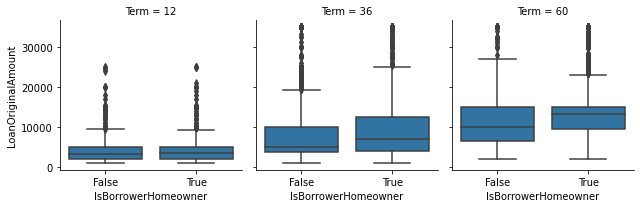

```python
g = sb.FacetGrid(data = loan_data, col = 'Term', height = 3);
g.map(sb.boxplot, 'IsBorrowerHomeowner', 'LoanOriginalAmount');
```

> The average loan amount for a `1-year` loan term is the same for homeowners and non-homeowner and the average of homeowners starts to be greater starting from the `3-Year` loan term.

### Talk about some of the relationships you observed in this part of the investigation. Were there features that strengthened each other in terms of looking at your feature(s) of interest?

> Increasing loan amount and terms with the income range also the homeowner has the greater loan amount and terms.

### Were there any interesting or surprising interactions between features?

> For Prosper Rating `(HR-C)`, the Loan term decreases with the increase of Borrower APR but for starting from Prosper Rating `(B)`, the loan term increase with the increasing of Borrower APR, and for the `1-Year` term, homeowner and non-homeowner are having the same loan amount average.